# My solution to the challenge

Gerko Vink

The following packages are required for this practical:

```r
library(dplyr)
library(magrittr)
library(mice)
library(ggplot2)
```

The basis of the data relations is captured in the variance/covariance matrix and how it translates to data relations. This is most easily linearly summarized in the correlation matrix:

```r
mammalsleep %>%
  subset(select = -species) %>% #exclude factor species
  cor(use = "pairwise.complete.obs") #pairwise deletion
```

```
##              bw         brw        sws         ps         ts         mls
## bw   1.00000000  0.93416384 -0.3759462 -0.1093833 -0.3071859  0.30245056
## brw  0.93416384  1.00000000 -0.3692177 -0.1051388 -0.3581020  0.50925268
## sws -0.37594625 -0.36921766  1.0000000  0.5142539  0.9627147 -0.38443179
## ps  -0.10938331 -0.10513879  0.5142539  1.0000000  0.7270870 -0.29574535
## ts  -0.30718591 -0.35810203  0.9627147  0.7270870  1.0000000 -0.41020239
## mls  0.30245056  0.50925268 -0.3844318 -0.2957453 -0.4102024  1.00000000
## gt   0.65110218  0.74724248 -0.5947028 -0.4508987 -0.6313262  0.61484879
## pi   0.05949472  0.03385548 -0.3181846 -0.4474705 -0.3958350 -0.10254416
## sei  0.33827367  0.36780037 -0.5437566 -0.5372245 -0.6422845  0.36035221
## odi  0.13358123  0.14587888 -0.4838522 -0.5793365 -0.5877424  0.06177846
##             gt          pi        sei         odi
## bw   0.6511022  0.05949472  0.3382737  0.13358123
## brw  0.7472425  0.03385548  0.3678004  0.14587888
## sws -0.5947028 -0.31818462 -0.5437566 -0.48385220
## ps  -0.4508987 -0.44747050 -0.5372245 -0.57933653
## ts  -0.6313262 -0.39583497 -0.6422845 -0.58774241
## mls  0.6148488 -0.10254416  0.3603522  0.06177846
## gt   1.0000000  0.20050426  0.6382790  0.37861701
## pi   0.2005043  1.00000000  0.6182460  0.91604245
## sei  0.6382790  0.61824597  1.0000000  0.78720311
## odi  0.3786170  0.91604245  0.7872031  1.00000000
```

This matrix contains quite a few cells. To obtain only the correlations with `sws` we could select the respective column:

```r
mammalsleep %>%
  subset(select = -species) %>% #exclude factor species
  cor(use = "pairwise.complete.obs") %>% #pairwise deletion
  subset(select = sws) #only column sws from the correlation matrix
```

```
##            sws
## bw  -0.3759462
## brw -0.3692177
## sws  1.0000000
## ps   0.5142539
## ts   0.9627147
## mls -0.3844318
## gt  -0.5947028
## pi  -0.3181846
## sei -0.5437566
## odi -0.4838522
```

It seems that the following variables have a rather nice relation with `sws`. As a matter of fact, all predictors do. However, we first focus on this subset:

- `ps`: paradoxical sleep
- `ts` : total sleep
- `gt` : gestation time
- `sei`: sleep exposure index
- `odi`: overall danger index

```r
mammalsleep %>%
  summary()
```

```
##                       species         bw                brw
##  African elephant         : 1   Min.   :   0.005   Min.   :   0.14
##  African giant pouched rat: 1   1st Qu.:   0.600   1st Qu.:   4.25
##  Arctic Fox               : 1   Median :   3.342   Median :  17.25
##  Arctic ground squirrel   : 1   Mean   : 198.790   Mean   : 283.13
##  Asian elephant           : 1   3rd Qu.:  48.202   3rd Qu.: 166.00
##  Baboon                   : 1   Max.   :6654.000   Max.   :5712.00
##  (Other)                  :56
##       sws               ps              ts             mls
##  Min.   : 2.100   Min.   :0.000   Min.   : 2.60   Min.   :  2.000
##  1st Qu.: 6.250   1st Qu.:0.900   1st Qu.: 8.05   1st Qu.:  6.625
##  Median : 8.350   Median :1.800   Median :10.45   Median : 15.100
##  Mean   : 8.673   Mean   :1.972   Mean   :10.53   Mean   : 19.878
##  3rd Qu.:11.000   3rd Qu.:2.550   3rd Qu.:13.20   3rd Qu.: 27.750
##  Max.   :17.900   Max.   :6.600   Max.   :19.90   Max.   :100.000
##  NA's   :14       NA's   :12      NA's   :4       NA's   :4
##        gt               pi             sei             odi
##  Min.   : 12.00   Min.   :1.000   Min.   :1.000   Min.   :1.000
##  1st Qu.: 35.75   1st Qu.:2.000   1st Qu.:1.000   1st Qu.:1.000
##  Median : 79.00   Median :3.000   Median :2.000   Median :2.000
##  Mean   :142.35   Mean   :2.871   Mean   :2.419   Mean   :2.613
##  3rd Qu.:207.50   3rd Qu.:4.000   3rd Qu.:4.000   3rd Qu.:4.000
##  Max.   :645.00   Max.   :5.000   Max.   :5.000   Max.   :5.000
##  NA's   :4
```

Because of the missingness argument it could be highly preferable to use `ts` in the model.

We run the new model:

```r
fit <-
  mammalsleep %$%
  lm(sws ~ ts + gt + sei + odi)

fit %>%
  summary()
```

```
##
## Call:
## lm(formula = sws ~ ts + gt + sei + odi)
##
## Residuals:
##     Min      1Q  Median      3Q     Max
## -2.7691 -0.4651  0.0313  0.5544  1.9150
##
## Coefficients:
##               Estimate Std. Error t value Pr(>|t|)
## (Intercept) -0.6300245  0.8673334  -0.726    0.472
## ts           0.8245123  0.0478859  17.218   <2e-16 ***
## gt           0.0001013  0.0017236   0.059    0.953
## sei         -0.0483717  0.1905811  -0.254    0.801
## odi          0.2505529  0.1940861   1.291    0.204
## ---
## Signif. codes:  0 '***' 0.001 '**' 0.01 '*' 0.05 '.' 0.1 ' ' 1
##
## Residual standard error: 0.9701 on 39 degrees of freedom
##   (18 observations deleted due to missingness)
## Multiple R-squared:  0.9393, Adjusted R-squared:  0.933
## F-statistic: 150.8 on 4 and 39 DF,  p-value: < 2.2e-16
```

and we have obtained a very high $R^2$, even though only one predictor is significant. If prediction was our goal, we are doing great: the $R^2$ indicates that our predicted outcome correlates $\rho = .969$ with the observed outcome.

## Some further diagnostic checking of this model

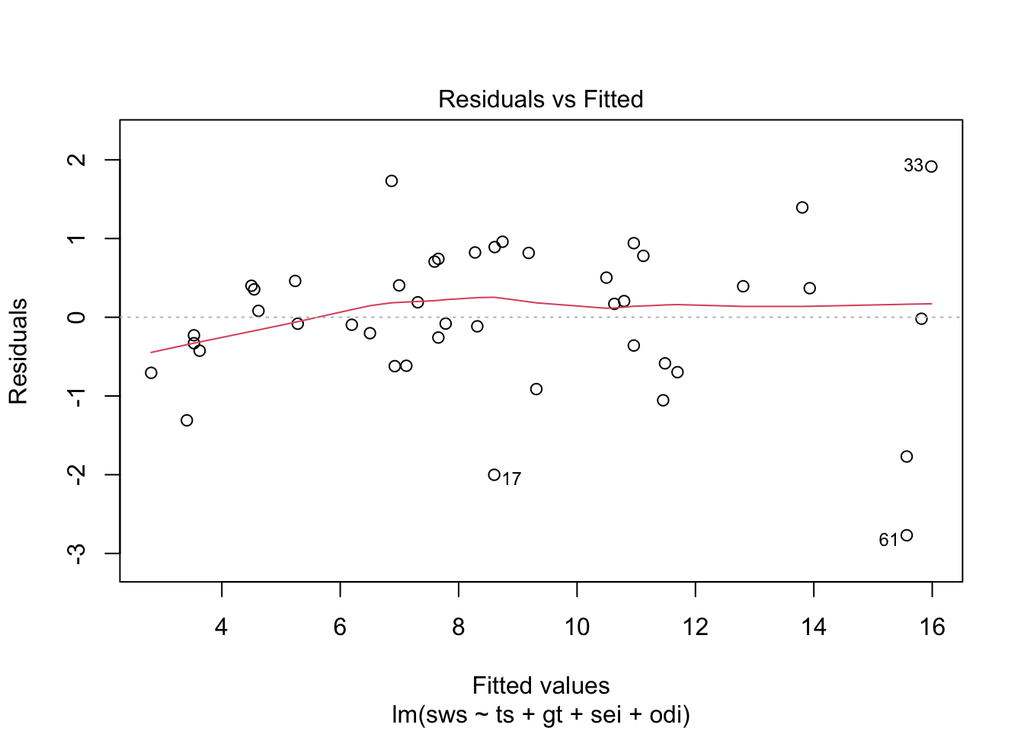

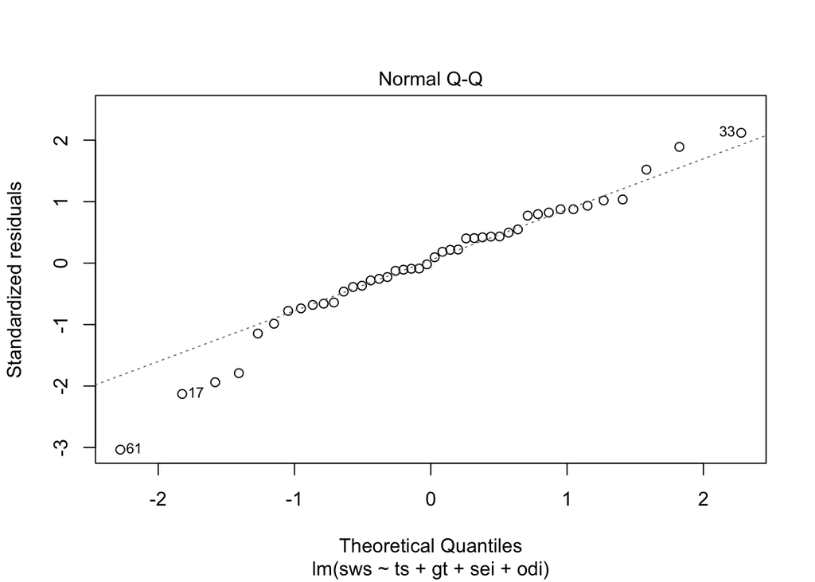

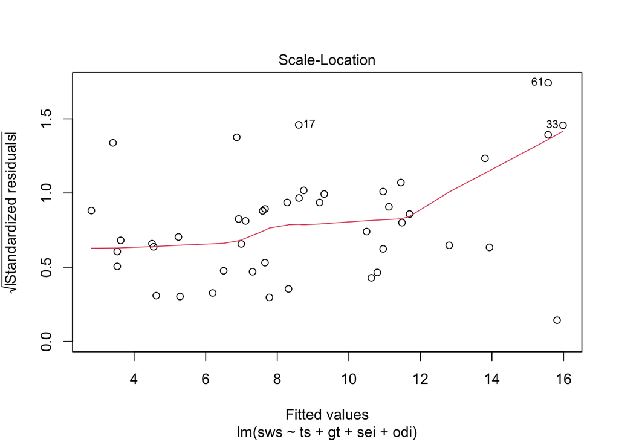

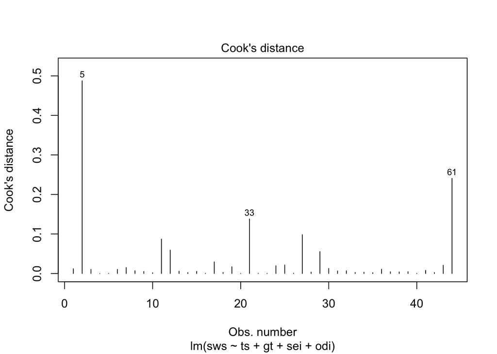

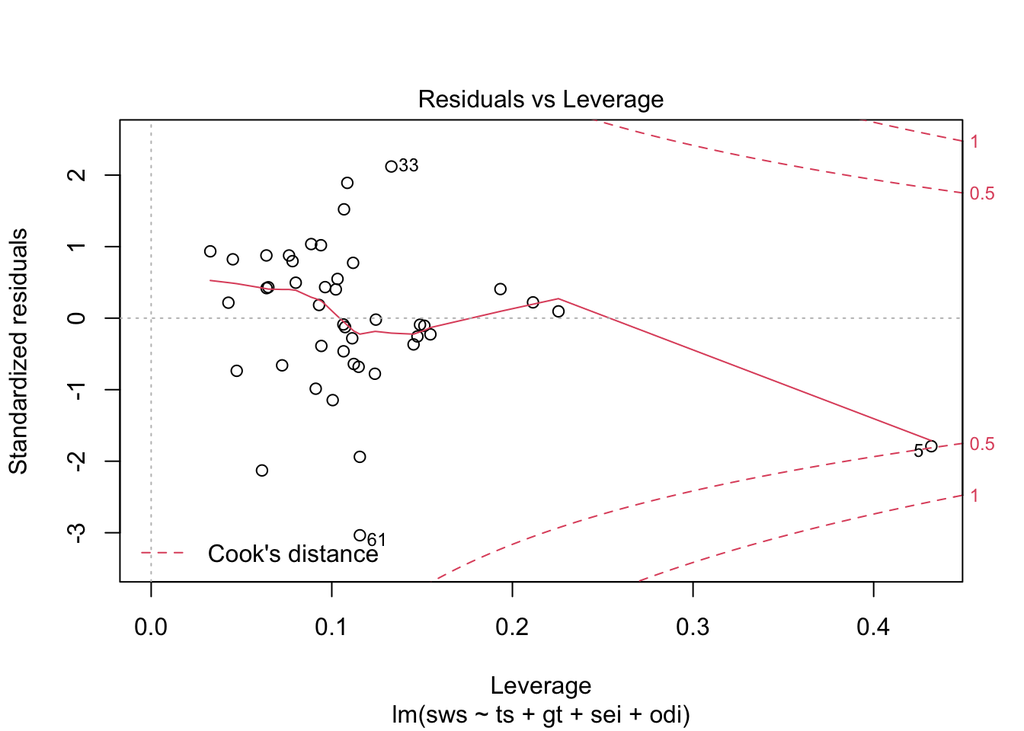

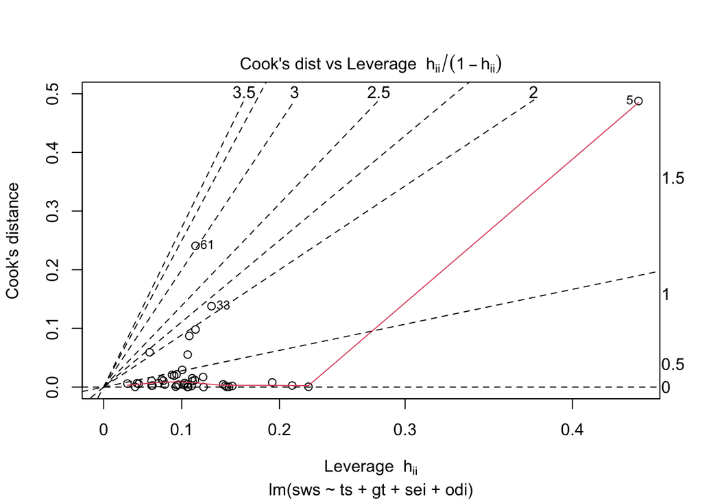

```r
fit %>%
  plot(which = 1:6)
```

Some issues spring to mind:

- There error variance seems to be heteroscedastic [but we have a rather small sample]
- The residuals are not normally distributed in the extreme tails
- The following case has a large leverage: 5
- The following case has large residual: 61
- Case 33 still has a large Cook’s distance (no alarming residual or leverage)

```r
mammalsleep$species[c(5, 33, 61)]
```

```
## [1] Asian elephant   Little brown bat Water opossum
## 62 Levels: African elephant African giant pouched rat ... Yellow-bellied marmot
```

If we sort the data based on `sws`:

```r
mammalsleep %>%
  arrange(desc(sws)) #sort the data in descending order based on sws
```

```
##                      species       bw     brw  sws  ps   ts   mls    gt pi sei
## 1           Little brown bat    0.010    0.25 17.9 2.0 19.9  24.0  50.0  1   1
## 2              Big brown bat    0.023    0.30 15.8 3.9 19.7  19.0  35.0  1   1
## 3                 Owl monkey    0.480   15.50 15.2 1.8 17.0  12.0 140.0  2   2
## 4      Nine-banded armadillo    3.500   10.80 14.3 3.1 17.4   6.5 120.0  2   1
## 5        N. American opossum    1.700    6.30 13.8 5.6 19.4   5.0  12.0  2   1
## 6                 Tree shrew    0.104    2.50 13.2 2.6 15.8   2.3  46.0  3   2
## 7              Water opossum    3.500    3.90 12.8 6.6 19.4   3.0  14.0  2   1
## 8            Giant armadillo   60.000   81.00 12.0 6.1 18.1   7.0    NA  1   1
## 9                      Mouse    0.023    0.40 11.9 1.3 13.2   3.2  19.0  4   1
## 10                Phanlanger    1.620   11.40 11.9 1.8 13.7  13.0  17.0  2   1
## 11                Chinchilla    0.425    6.40 11.0 1.5 12.5   7.0 112.0  5   4
## 12            Golden hamster    0.120    1.00 11.0 3.4 14.4   3.9  16.0  3   1
## 13                    Tenrec    0.900    2.60 11.0 2.3 13.3   4.5  60.0  2   1
## 14                       Cat    3.300   25.60 10.9 3.6 14.5  28.0  63.0  1   2
```

[output cut: 111 more lines]

we see that high `sws` is primarily for lighter mammals without real predatory enemies.

```r
fit %>%
  residuals()
```

```
##           2           5           6           7           8           9
## -0.62096988 -1.30915398  0.82284099 -0.01859457 -0.08202438 -0.58559621
##          10          11          12          15          16          17
##  0.70676933  0.50354811 -0.42495182 -0.20231531  1.73201966 -2.00087466
##          18          22          23          25          27          28
##  0.89122186 -0.22902414 -0.69730728  0.08119960 -1.05436874  0.40503745
##          29          32          33          34          35          36
## -0.70601252 -0.08068364  1.91498308 -0.09530892 -0.11502636 -0.91235942
##          37          38          39          40          42          43
##  0.94125056  0.16994087 -1.76891037  0.36917086  1.39476808  0.81689078
##          44          45          46          48          49          50
##  0.77974998 -0.61625560  0.19007469 -0.35895210 -0.25764574  0.74209872
##          51          52          54          57          58          59
##  0.46108282  0.39994464 -0.32932812  0.20519783  0.35410605  0.39370751
##          60          61
##  0.95917331 -2.76911303
```

## Model with all predictors

If we run a model with all predictors, we end up with

```r
fit <-
  mammalsleep %$%
  lm(sws ~ bw + brw + ps + ts + mls + gt + pi + sei + odi)

fit %>%
  summary()
```

```
##
## Call:
## lm(formula = sws ~ bw + brw + ps + ts + mls + gt + pi + sei +
##     odi)
##
## Residuals:
##        Min         1Q     Median         3Q        Max
## -1.554e-15 -1.034e-15 -2.690e-17  7.613e-16  3.985e-15
##
## Coefficients:
##               Estimate Std. Error    t value Pr(>|t|)
## (Intercept)  3.035e-16  1.489e-15  2.040e-01    0.840
## bw           2.066e-18  2.606e-18  7.930e-01    0.434
## brw         -1.087e-18  1.549e-18 -7.020e-01    0.488
## ps          -1.000e+00  2.564e-16 -3.900e+15   <2e-16 ***
## ts           1.000e+00  7.930e-17  1.261e+16   <2e-16 ***
## mls          9.876e-18  2.036e-17  4.850e-01    0.631
## gt          -1.798e-18  3.429e-18 -5.240e-01    0.604
## pi          -2.703e-16  5.323e-16 -5.080e-01    0.615
## sei         -2.586e-16  3.102e-16 -8.340e-01    0.411
## odi          3.169e-16  7.523e-16  4.210e-01    0.676
## ---
## Signif. codes:  0 '***' 0.001 '**' 0.01 '*' 0.05 '.' 0.1 ' ' 1
##
## Residual standard error: 1.32e-15 on 32 degrees of freedom
##   (20 observations deleted due to missingness)
## Multiple R-squared:      1,  Adjusted R-squared:      1
## F-statistic: 3.849e+31 on 9 and 32 DF,  p-value: < 2.2e-16
```

This system is linearly dependent; we have the correct answer in the system `sws = ts - ps`. This may not be informative, even though our $R^2$ indicates perfection. In contrast, when we remove `ts`, the $R^2$ naturally drops dramatically. If we remove both `ts` and `ps` a completely different system emerges, but the $R^2$ drops dramatically:

```r
fit <-
  mammalsleep %$%
  lm(sws ~ bw + brw + mls + gt + pi + sei + odi)

fit %>%
  summary()
```

```
##
## Call:
## lm(formula = sws ~ bw + brw + mls + gt + pi + sei + odi)
##
## Residuals:
##     Min      1Q  Median      3Q     Max
## -5.2864 -1.6503 -0.4501  1.4037  6.4473
##
## Coefficients:
##              Estimate Std. Error t value Pr(>|t|)
## (Intercept) 13.331488   1.256475  10.610  2.5e-12 ***
## bw           0.003332   0.005568   0.598   0.5535
## brw         -0.001294   0.003342  -0.387   0.7010
## mls         -0.001181   0.043509  -0.027   0.9785
## gt          -0.013804   0.006563  -2.103   0.0429 *
## pi           1.414774   1.027350   1.377   0.1775
## sei          0.224418   0.643644   0.349   0.7295
## odi         -2.799115   1.275630  -2.194   0.0351 *
## ---
## Signif. codes:  0 '***' 0.001 '**' 0.01 '*' 0.05 '.' 0.1 ' ' 1
##
## Residual standard error: 2.857 on 34 degrees of freedom
##   (20 observations deleted due to missingness)
## Multiple R-squared:  0.5404, Adjusted R-squared:  0.4458
## F-statistic: 5.711 on 7 and 34 DF,  p-value: 0.0002014
```

## Conclusion

These data are very inter-related. So much so, that it is hard to group all these mammals together in a single linear model. There will always be large residuals: most animals that are really have need quite a lot of food and have no time to eat. Yet, this data set contains only a few of those animals. Other animals are not quite heavy, but still sleep a lot. Take e.g. ourselves (measured in this data set as `man`): We are light, have massive brains and sleep quite a lot - yet we are nowhere near the region in the foodchain any model would expect us to be.

Bottomline: not all data sets lend themselves for inference based on linear models - at least not without some serious data cleaning and/or feature transformation. That said, it is not hard to find a good fitting and well-performing predictive model in this data set.

End of `Challenge`.